# Example simulation experiment for UK MSM source attribution

Erik Volz

March 24, 2016

This document demonstrates the following:

- Simulating tree from UK MSM model
- Computing infector probs
- Some simple analyses comparing infector probabilities by stage of infection, age and risk level

Load the libraries and model code:

```r
require(phydynR)
source('model0.R')
```

Simulate an epidemic (ODE model)

```r
    o <- ode(y=y0, times=times_day, func=dydt, parms=list()  , method = 'adams')
    tfgy <- .tfgy( o )
```

For computing the approximate infector probabilities, we will make approximation that incidence and prevalence is constant over a given period; we can base this on the model:

```r
MH <- 10 # look up to 10 years in past for infector probs
#~ incidence and prevalence :
yfin <- tfgy[[4]][[length(times_day)]]
ffin <- tfgy[[2]][[length(times_day)]]
newinf <- sum(ffin[1:120, 1:120] ) * 365  # new infections per year
plwhiv <- sum( yfin[-length(yfin)] ) # people living with hiv
```

Gather the sample time and sample state information; this is based on the real data set:

```r
#~  sample time and states
sampleTimes <- scan( file = 'sampleTimes' )
ss  <- matrix( scan( file = 'sampleStates' ) , byrow=TRUE, ncol = m)
colnames(ss) <- DEMES
# regularise (estimates are more stable w/o zeros in sample states)
ss <- ss + 1e-4
ss = sampleStates <- ss / rowSums(ss)
```

Simulate a tree; note that I changed the time interval to weekly, so it will take longer to run (should be <5 minutes).

```r
    tree <- sim.co.tree.fgy(tfgy,  sampleTimes, sampleStates)
```

We need to put everything in time units of years, since that is the expectation of the SA method; rescale the branch lengths and sample times:

```r
# rescale tree
sampleTimes <- days2years( tree$sampleTimes )
tree$edge.length <- tree$edge.length / 365
#~ bdt <- DatedTree(  tree, sampleTimes, tree$sampleStates, tol = Inf )
bdt <- DatedTree(  tree, sampleTimes, tree$sampleStates, tol = Inf)
n<- bdt$n
```

Collect the CD4 and EHI indicators for each sample; these are inputs to the SA method:

```r
## cd4s & ehis
    # from cori paper
    #~ k =1: CD4>=500
    #~ k = 2 : 350<=CD4<500.
    #~ k = 3: 200<=CD4<350
    #~ k = 4 : CD4<200
treeSampleStates <- tree$sampleStates
cd4s <- setNames( sapply( 1:nrow(treeSampleStates), function(k){
    deme <- DEMES[ which.max(treeSampleStates[k,] )  ]
    stage <- strsplit( deme, '.' , fixed=T)[[1]][1]
    stage <- as.numeric( tail( strsplit(stage, '')[[1]], 1 ) )
    if (stage==1) return(1e3)
    if (stage==2) return(750)
    if (stage==3) return(400)
    if (stage==4) return(300)
    if (stage==5) return(100)
}), tree$tip.label)
ehis <-  setNames( sapply( 1:nrow( treeSampleStates), function(k){
    deme <- DEMES[ which.max(treeSampleStates[k,] )  ]
    stage <- strsplit( deme, '.' , fixed=T)[[1]][1]
    stage <- as.numeric( tail( strsplit(stage, '')[[1]], 1 ) )
    ifelse( stage==1, TRUE, FALSE)
}), tree$tip.label)
sampleDemes <- setNames( sapply( 1:n, function(u) DEMES[which.max( treeSampleStates[u,])] ), tree$tip.label )
```

Now we can comput infector probabilities:

```r
    W <- phylo.source.attribution.hiv( bdt
      , bdt$sampleTimes # must use years
      , cd4s = cd4s[bdt$tip.label] # named numeric vector, cd4 at time of sampling
      , ehi = ehis[bdt$tip.label] # named logical vector, may be NA, TRUE if patient sampled with early HIV infection (6 mos )
      , numberPeopleLivingWithHIV  = plwhiv# scalar
      , numberNewInfectionsPerYear = newinf # scalar
      , maxHeight = MH
      , res = 1e3
      , treeErrorTol = Inf
    )
```

```
## [1] "NOTE : sample times must be in units of years"
## [1] "start source attrib"
## [1] "Thu Mar 24 14:06:04 2016"
## [1] "source attrib complete"
## [1] "Thu Mar 24 14:06:20 2016"
```

## Some simple comparisons of infector probabilities by stage, age, risk level

The total number of transmission events within-sample:

```r
wsids <- unique( W$donor )
wvec <- W$infectorProbability
wvec_o <- order( wvec )
wvec <- wvec[wvec_o] # sort the inf probs
print ('sum w')
```

```
## [1] "sum w"
```

```r
print(sum(wvec))
```

```
## [1] 1759.18
```

Compute out-degree, indegree, and compare:

```r
## out degree & indegree
od <- sapply( wsids, function(sid) sum( wvec[W$donor[wvec_o]==sid]  ) )
mod <- sapply( wsids, function(sid) max( wvec[W$donor[wvec_o]==sid]  ) )
id <- sapply( wsids, function(sid) sum( wvec[W$recip[wvec_o]==sid]  ) )
X11(); plot( od, id, log = 'xy' , main = 'Out degree vs in degree')
X11(); hist( od , main = 'Histogram of out degree')
X11(); plot( ecdf( od ), main= 'CDF of out degree')
```

[output not shown]

Comparison of out-degree as function of stage at diagnosis:

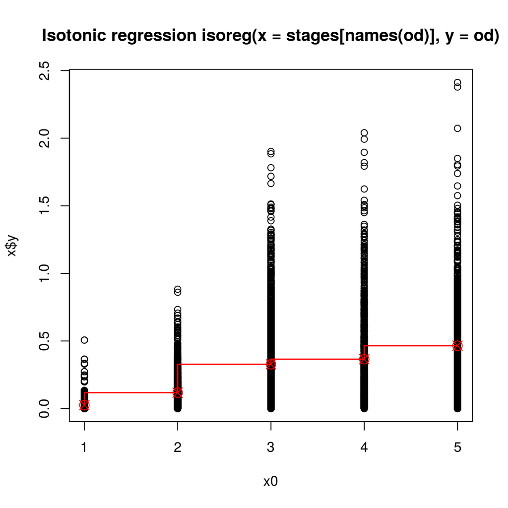

```
## [1] "cor( stages[names(od)] , od  )"
```

```r
.cd42stage <- function(cd4)
{
    # from cori paper
    #~ k =1: CD4>=500
    #~ k = 2 : 350<=CD4<500.
    #~ k = 3: 200<=CD4<350
    #~ k = 4 : CD4<200
    if (is.na(cd4) ) return (NA)
    if (cd4  >= 500) return (2)
    if (cd4 >= 350) return(3)
    if (cd4 >= 200 ) return(4)
    return(5)
}
cd4s <- cd4s[bdt$tip.label]
ehis <- ehis[bdt$tip.label]
stages <- sapply( cd4s, .cd42stage )
for (i in 1:length(ehis)){
    if (!is.na(ehis[i])){
        if (ehis[i]) stages[i] <- 1
    }
}
od_by_stage <- lapply( 1:5, function(stage) od[names(od) %in% names(stages[stages==stage])] )
## isotonic regression stage :
ir_stage <- isoreg( stages[names(od)] , od )
X11(); plot( ir_stage  )
print( 'cor( stages[names(od)] , od  )' )
```

```r
print( cor( stages[names(od)] , od  ) )
```

```
## [1] 0.4865108
```

Do a comparison of out degree by age group of the patient at diagnosis:

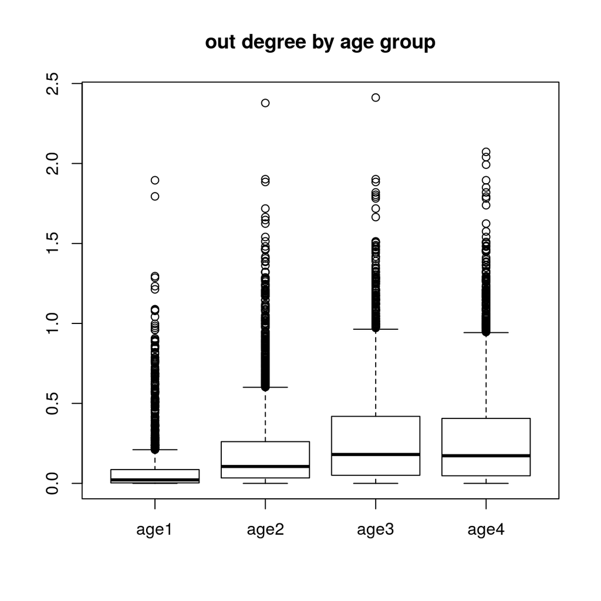

```
##
##  Kruskal-Wallis rank sum test
##
## data:  od_age
## Kruskal-Wallis chi-squared = 1061.8, df = 3, p-value < 2.2e-16
```

```r
#~ assoc of outdegree & age
age_ids <- paste(sep='', 'age', 1:4)
age_sids <- setNames( lapply( age_ids, function(ageid) grepl(  ageid, sampleDemes[names(od)] ) ) , age_ids )
od_age <- setNames(  lapply( age_ids, function(ageid) od[ age_sids[[ageid]] ] ), age_ids )
X11() ; boxplot(  od_age , main = 'out degree by age group')
print ( ( kruskal.test( od_age ) ))
```

Now compare differences in out degree by risk level:

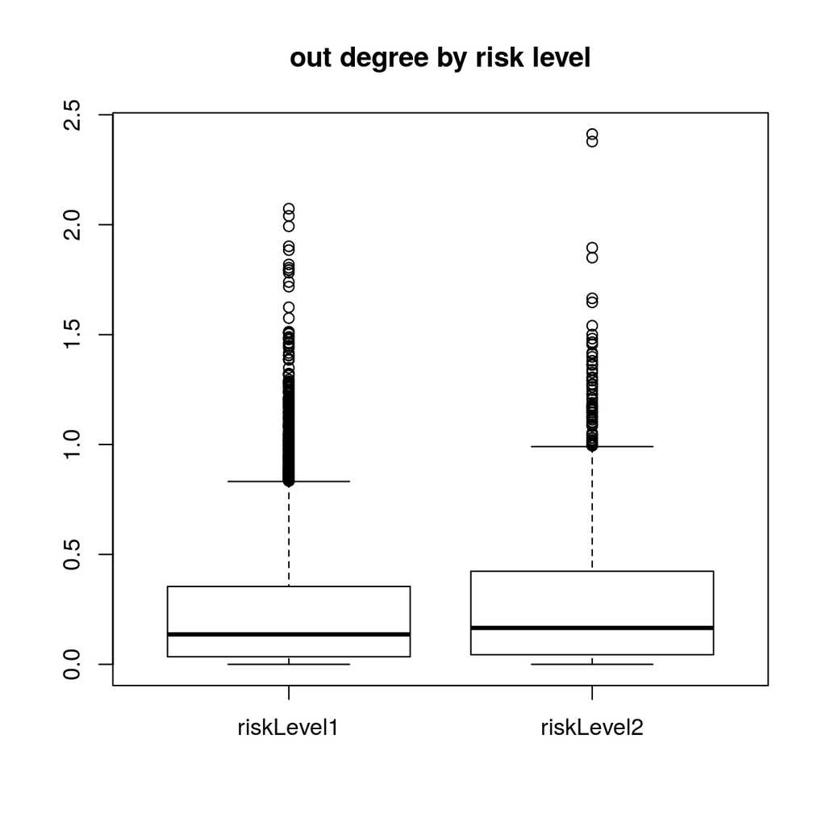

```
##
##  Wilcoxon rank sum test with continuity correction
##
## data:  od_rl[[1]] and od_rl[[2]]
## W = 3566700, p-value = 0.0001216
## alternative hypothesis: true location shift is not equal to 0
```

```r
#~ assoc of risk level & outdegree
rl_ids <- c( 'riskLevel1', 'riskLevel2' )
# sequence IDs in each risk level:
rl_sids <- setNames( lapply( rl_ids, function(rlid) grepl( rlid, sampleDemes[ names(od) ] ) ), rl_ids )
# out degree for each risk level:
od_rl <- setNames( lapply( rl_ids, function(rlid) od[ rl_sids[[rlid]] ] ), rl_ids )

X11() ; boxplot(  od_rl , main = 'out degree by risk level')
print ( ( wilcox.test( od_rl[[1]], od_rl[[2]] ) ))
```

And the ratio of out degree of RL2 to RL1:

```r
print(mean( od_rl[[2]]) / mean(od_rl[[1]]) )
```

```
## [1] 1.189222
```

Note that difference is detectable, but much smaller than the true difference in transmission rates; what does clustering say about it?

## Summary

- Out degree is increasing in age and stage, consistent with interpretation of out-degree as proportional to cumulative number of infections
- These patterns need to be characterised in real data
- Similar analyses need to be done using genetic-distance clustering; it will likely show opposite trends with respect to age and stage; sensitivity to detecting a difference in risk level needs to be characterised
- Counterfactual simulations (equal rates) need to be done to assess false-positive inference of clustering and SA
- Variation in transmission rates by stage is difficult to estimate using SA but Erik will continue to look into it
- Similarly, also need to examine assortativity by age; this can be compared to true level of assortativity in simulations, and can characterise false positive rates for clustering & SA